# R Bootcamp: Day 3 PM

## Probability (sort of) and simulation in R

Eric Manning

September 1, 2026

princeton-ddss.github.io/r-bootcamp

## This session

### 1) Drawing random numbers

- `sample()`, `set.seed()`, and a couple of named distributions
- The `d`/`p`/`q`/`r` family

### 2) Simulation

- Wax on, wax off

We are **not** teaching statistics today. We are showing you the machinery, so the concepts seem vaguely familiar later.

## Some sources

- Long and Teetor, *R Cookbook*, 2e
  - [Ch. 8: Probability](https://rc2e.com/probability) — the whole chapter is recipes for today
- Harvard IQSS, *Math Prefresher for Political Scientists*
  - [Ch. 12: Simulation](https://iqss.github.io/prefresher/16_simulation.html) — where this afternoon’s exercise comes from
- Mercer, [A brief visualization of R’s distribution functions](https://wetlandscapes.com/blog/a-brief-visualization-of-rs-distribution-functions/)
- [Plot probability distribution function in R](https://www.geeksforgeeks.org/r-language/plot-probability-distribution-function-in-r/) (GeeksforGeeks)

**Additional:** [Geyer, *Distributions in R*](https://www.stat.umn.edu/geyer/old/5101/rlook.html) — a one-page lookup table for every distribution R ships with. Bookmark it.

# Drawing random numbers

## `sample()`: draw from a vector

Give it something to draw from and how many draws you want:

```r
sample(1:10, size = 5)
```

```
[1] 10  4  8  2  9
```

With no `size`, you get a **permutation** — the whole vector, reshuffled:

```r
sample(1:10)
```

```
 [1] 10  5  2  9  3  8  6  4  7  1
```

## With or without replacement

By default, each element can be drawn **once**. `size` can’t exceed the vector:

```r
sample(1:5, size = 10)
```

```
Error in `sample.int()`:
! cannot take a sample larger than the population when 'replace = FALSE'
```

`replace = TRUE` puts each draw back in the bag:

```r
sample(1:5, size = 10, replace = TRUE)
```

```
 [1] 2 4 1 5 1 3 2 3 1 1
```

## A coin, ten times

The vector doesn’t have to be numbers:

```r
sample(c("heads", "tails"), size = 10, replace = TRUE)
```

```
 [1] "tails" "heads" "heads" "tails" "tails" "heads" "heads" "heads" "heads"
[10] "heads"
```

## An unfair coin: `prob`

`prob` weights the draws. It lines up with the vector you’re sampling from:

```r
sample(c("heads", "tails"), size = 10, replace = TRUE, prob = c(0.9, 0.1))
```

```
 [1] "heads" "heads" "heads" "heads" "heads" "heads" "heads" "heads" "heads"
[10] "heads"
```

`prob` gets normalized, so `c(9, 1)` and `c(0.9, 0.1)` behave identically.

## Your results won’t match mine

Run the same line twice:

```r
sample(1:100, 4)
sample(1:100, 4)
```

```
[1] 32 74  6 51
[1] 44 29 63 14
```

Results are not reproducible between runs.

## `set.seed()`

R’s randomness is **not** random — it’s a deterministic sequence that looks random. `set.seed()` says where to start:

```r
set.seed(2026)
sample(1:100, 4)

set.seed(2026)
sample(1:100, 4)
```

```
[1] 93 97 38 45
[1] 93 97 38 45
```

## Using `set.seed()` in practice

- Set it **once**, near the top of the script, with any integer you like
- Then never touch it again in that script

## Two distributions worth naming

### Bernoulli

One trial, two outcomes, probability `p` of a 1/T/‘yes’/etc. *A (biased?) coin flip.*

### Uniform

Every value in a range is equally likely.

## Bernoulli draws: `rbinom()`

`size = 1` means one coin per draw; `prob` is the chance of a 1:

```r
set.seed(2026)
rbinom(n = 20, size = 1, prob = 0.5)
```

```
 [1] 1 1 0 0 1 0 0 1 0 1 0 1 0 1 0 0 1 0 0 0
```

Bump `size` and each draw becomes *“how many heads in `size` flips?”*:

```r
rbinom(n = 10, size = 100, prob = 0.5)
```

```
 [1] 54 54 56 57 45 53 50 54 50 54
```

## Uniform draws: `runif()`

`runif(n)` gives `n` values between 0 and 1, none more likely than any other:

```r
set.seed(2026)
runif(5)
```

```
[1] 0.6986735 0.5565305 0.1401400 0.2857233 0.5553690
```

`min` and `max` move the range:

```r
runif(5, min = 10, max = 20)
```

```
[1] 10.25131 14.66231 18.61011 12.52501 15.80806
```

## What “uniform” looks like

```r
set.seed(2026)
hist(runif(10000), breaks = 40, main = "10,000 draws from runif()")
```

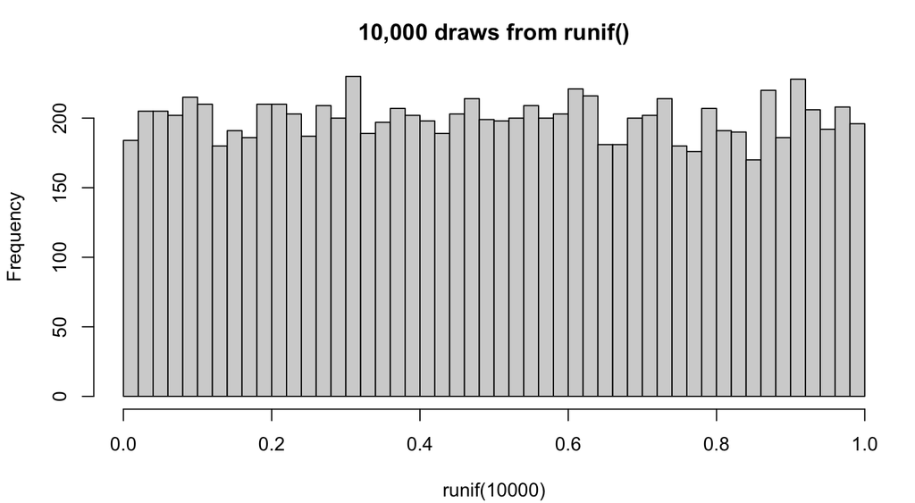

## And now one we’re not going to explain

```r
set.seed(2026)
hist(rnorm(10000), breaks = 40, main = "10,000 draws from rnorm()")
```

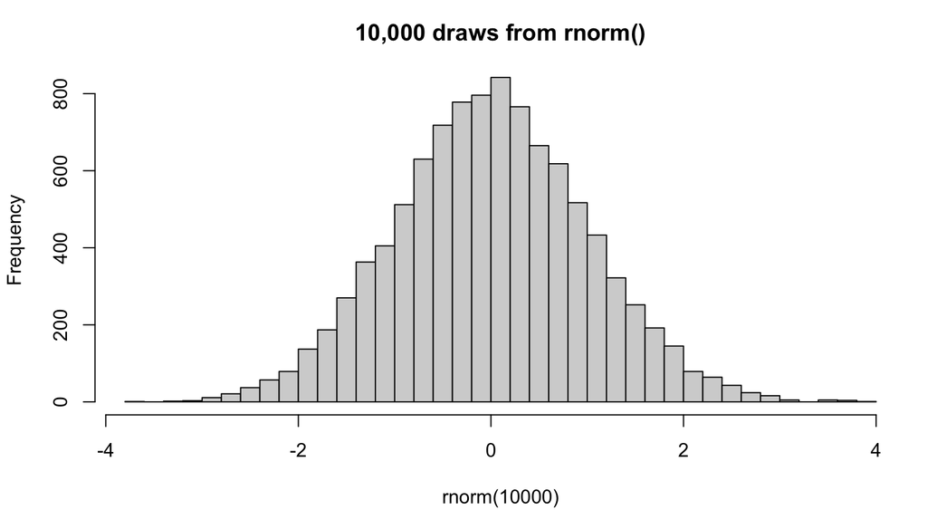

This is the **normal distribution**. Note the shape and move on.

## `rnorm()` arguments

`mean` centers it, `sd` sets its width. The defaults are 0 and 1:

```r
set.seed(2026)
rnorm(5)
rnorm(5, mean = 100, sd = 15)
```

```
[1]  0.52058907 -1.07969076  0.13923812 -0.08474878 -0.66663962
[1]  62.25866  88.97280  84.69817 101.70332  92.89314
```

Every `r*()` function follows this shape: how many draws, then the knobs for that distribution.

# The `d` / `p` / `q` / `r` family

## One distribution, four questions

Every distribution in R comes as four functions sharing one name stem:

| Prefix | Question it answers | Normal |
| --- | --- | --- |
| `r` | Give me random draws | `rnorm()` |
| `d` | How dense/tall is the curve here? | `dnorm()` |
| `p` | How much of the distribution’s mass lies below here? | `pnorm()` |
| `q` | Which value has this much below it? | `qnorm()` |

## Visualized

[figure not shown]

Jason Mercer, [“A brief visualization of R’s distribution functions”](https://wetlandscapes.com/blog/a-brief-visualization-of-rs-distribution-functions/) (2020).

## Reading that figure

Top row works on the **density** curve, bottom row on the **cumulative** curve:

- `dnorm()` — you hand it a value, it hands back the height of the curve
- `rnorm()` — draws values, more often where the curve is tall
- `pnorm()` — you hand it a value, it hands back the probability below it
- `qnorm()` — the inverse: hand it a probability, get the value

`p` and `q` undo each other.

## `p` and `q`

Half the curve lies below its center:

```r
pnorm(0)
```

```
[1] 0.5
```

Go the other way — which value has 2.5% of the curve below it?

```r
qnorm(0.025)
```

```
[1] -1.959964
```

And back again:

```r
pnorm(qnorm(0.025))
```

```
[1] 0.025
```

## `d` is not a probability

```r
dnorm(0)
```

```
[1] 0.3989423
```

0.399 is a *height* For a continuous distribution the probability of any exact value is zero.

Probability lives in **areas** under the curve (`pnorm()`). `dnorm()` is for drawing the curve.

## Drawing a density with `d`

`stat_function()` takes the function itself — no data frame needed:

```r
ggplot() +
    stat_function(fun = dnorm, xlim = c(-4, 4), linewidth = 1) +
    labs(x = NULL, y = "Density") +
    theme_minimal(base_size = 20)
```

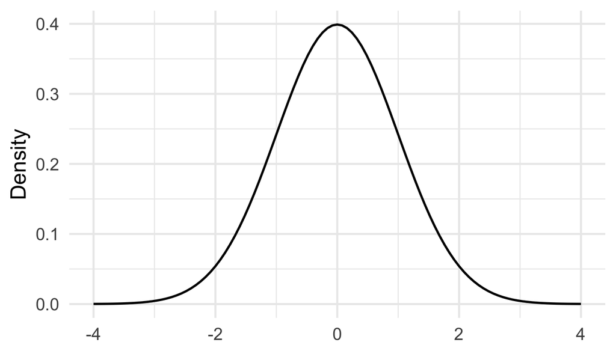

## `p` is the shaded area

```r
ggplot() +
    stat_function(fun = dnorm, xlim = c(-4, 4), linewidth = 1) +
    stat_function(
        fun = dnorm, xlim = c(-4, qnorm(0.025)),
        geom = "area", fill = "steelblue"
    ) +
    labs(x = NULL, y = "Density") +
    theme_minimal(base_size = 20)
```

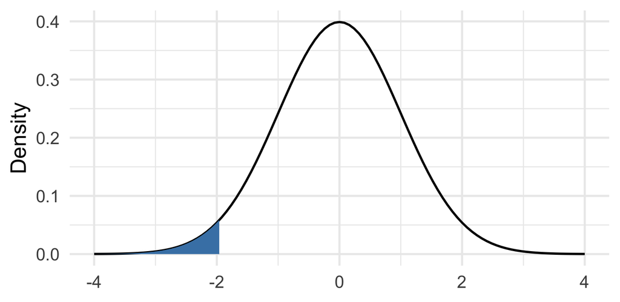

The blue strip runs from the far left up to `qnorm(0.025)` = -1.96, and its area is `pnorm(-1.96)` = 0.025.

**“2.5% of the distribution sits below -1.96.”**

## Every other distribution

`?Distributions` lists every one R ships with. Geyer’s [lookup table](https://www.stat.umn.edu/geyer/old/5101/rlook.html) is friendlier.

# Simulation

## Why

Some probability questions have clean formulas. Many do not.

## Recipe

**1.** Do the random thing **once**

**2.** Wrap it in a function that returns *one* number or `TRUE`/`FALSE`

**3.** Run that function **many** times

**4.** Summarize the results

## Step 1: do it once

*What’s the probability two dice sum to 7?*

```r
set.seed(2026)
dice <- sample(1:6, size = 2, replace = TRUE)
dice
sum(dice) == 7
```

```
[1] 5 1
[1] FALSE
```

## Step 2: wrap it in a function

```r
roll_is_7 <- function() {
    dice <- sample(1:6, size = 2, replace = TRUE)
    sum(dice) == 7
}

roll_is_7()
```

```
[1] TRUE
```

## Step 3: `replicate()`

`replicate(n, expr)` runs an expression `n` times and collects the results:

```r
set.seed(2026)
rolls <- replicate(10000, roll_is_7())

length(rolls)
head(rolls)
```

```
[1] 10000
[1] FALSE  TRUE FALSE FALSE FALSE FALSE
```

This is just a `for` loop.

## Step 4: summarize

```r
mean(rolls)
```

```
[1] 0.1654
```

The true answer is 6/36 = 0.1667.

## How many replications?

Run the whole simulation at different sizes and watch it settle:

```r
set.seed(2026)
sapply(
    c(10, 100, 1000, 10000, 100000),
    function(n) mean(replicate(n, roll_is_7()))
)
```

```
[1] 0.20000 0.15000 0.16300 0.16760 0.16661
```

More replications `==` **more precision in your estimate**.

# Resampling your own data

## Randomness from data, not a distribution

```r
set.seed(2026)
sample(counties$income, size = 5)
```

```
[1] 62496 57056 50635 57504 69826
```

Why?

**1. You have the population.** Draw samples (without replacement) to explore sampling variability. You choose (n), and seeing what changes as (n) changes is the point.

**2. You have one sample of a population.** Resample its observations with replacement, treating the resample as a stand-in for the population. This is the **bootstrap**. Variation among the bootstrap iterations helps us quantify uncertainty in the estimate derived from the observed sample.

## The bootstrap

You have 50 observations. You want to know how much your estimate would have varied if you’d drawn a *different* 50.

You can’t — there’s only one dataset, but we can treat the sample as if it were the population and redraw from it **at the same size**:

```r
set.seed(2026)
my_sample <- sample(counties$income, size = 50)

mean(sample(my_sample, size = 50, replace = TRUE))
```

```
[1] 64069.1
```

Do that 10,000 times.

If you don’t bootstrap with the same size, you have to apply a correction factor.

## Useful tools

- `boot::boot()` — the classic implementation, several kinds of interval; will apply correction factors
- `rsample::bootstraps()` — tidyverse-flavored

Both do exactly what we just did – and other stuff.

## Big data paradox

[Meng (2018)](https://statistics.fas.harvard.edu/sites/g/files/omnuum10116/files/statistics-2/files/statistical_paradises_and_paradoxes.pdf) examines a 2016 election survey with **2.3 million** respondents — about 1% of the American electorate.

Its tiny non-randomness meant it carried the same error as a genuine random sample of about **400 people**.

## Simulation exercises

Render as you go. No AI tools.  
princeton-ddss.github.io/r-bootcamp/notes/day-3-sim-ex.pdf

| Function | What it does |
| --- | --- |
| `sample(x, size, replace, prob)` | Draw from a vector |
| `set.seed(n)` | Make the draws reproducible |
| `runif(n, min, max)` | Uniform draws |
| `rbinom(n, size, prob)` | Coin flips / counts of successes |
| `rnorm(n, mean, sd)` | Normal draws |
| `dnorm()` / `pnorm()` / `qnorm()` | Height / area below / inverse |
| `replicate(n, expr)` | Run an expression `n` times, keep results |
| `mean(logical_vector)` | Proportion `TRUE` |
| `quantile(x, probs)` | Cut points of a set of numbers |